# ScienceWorld_DataLit slides

## Data Literacy in the Classroom

#### Laura Gutierrez Funderburk (Cybera)

#### Michael Lamoureux (U. Calgary)

[figure not shown]

## What is data literacy?

- Using data to inform decisions
- Reading, working with, analyzing, and arguing with data
- How to find good data, how to extract useful information from data

## Example -- Global warming?

- Where do we get data? (e.g. Vancouver temp data)
- How do we analyze it? (e.g. Spread sheet. Plot it)
- Deeper analysis? (e.g. linear trend in temperature)
- Go further (Other cities? Other sources of data?)

Vancouver data source:

- https://vancouver.weatherstats.ca/charts/temperature-wyearly.html
- 1935-2020

[figure not shown]

## Trend line $y = 0.00123 x + 6.778$

- x is measured in months, so temperature is rising at .00123 degrees per month
- $ .00123 * 12 * 100 = 1.5 $ degrees per century.

### Looks like a significant rise over a long period

# Summary

Data Literacy

- We used available data to look for trends
- We used computational tools to put a number to it
- We can argue, with data, as to the significance of that number

Going further

- Can we access more data? (Other cities? Satellites? etc?)
- Do we have better tools?

# Better tools

Jupyter Notebooks

Callysto Project

Notebook Repositories

Open Data Repositories

# Jupyter notebooks

This slideshow is actually a Jupyter notebook.

A web browser-based document, combining text, computer code, and graphics.

It is live, you can edit and use it as you present your stuff.

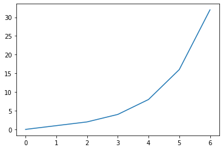

```python
# This is live code. You can change it!
import matplotlib.pyplot as plt

plt.plot([0,1,2,4,8,16,32]);
```

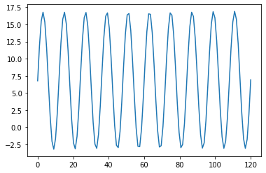

```python
# A simulation of temperatures
import numpy as np
x = np.linspace(0,12*10,num=12*10)
y = 0.00123*x+6.778 + 10*np.sin(2*np.pi*x/12)
plt.plot(x,y);
```

# Callysto project

Partnership of **Cybera Inc** (Alta) and the **Pacific Institute for the Mathematical Sciences**

Funded by **CanCode** (Canadian Gov't)

Resources for teachers, students to learn coding, data science, computational thinking.

Web: callysto.ca

## Sample notebooks at Callysto

[figure not shown]

# Social Justice and Computational Thinking

#### Laura Gutierrez Funderburk (SFU)

#### Richard Hoshino, (Quest)

#### Michael Lamoureux, (U Calgary)

## Motivation

How do small advantages, repeated over time, contribute to the success of an individual?

Does this make a difference in what we see as fairness, or justice, in real life?

Can we make a simulation of this, and explore any remediations?

## Example: Socio-economic status

Suppose Alice and Bob are both going to the same university.

Alice has money, lives close to campus, has a car, doesn't need a job for support.

Bob has no money, lives far from campus, takes transit, has a part-time job for tuition.

Does Alice end up more successful than Bob?

## Let's replace with a game of dice.

[figure not shown]

Alice and Bob each roll a die. The one with a bigger number wins. Ties go to Alice.

Starting with ten dollars each, at each roll the winner takes a dollar from the loser.

Let's play. Play until someone runs out of money.

## In class: Let's Play

Break up the students into groups of two (Alice and Bob).

Give each student ten candies, and a die. Have them roll the dice, and trade candy until someone runs out.

Count up how many Alices won all the candy? How many Bobs won them all?

Is this fair?

## Simulating the Game

Let's use some code to simulate many trials of this unfair game.

Try making it more fair. Change the starting points, or the payoffs.

```python
display(tab)
```

[output not shown]

## What can we take away from this?

1. Notice a slight advantages can significantly change the outcome when repeated over several iterations.
2. The "losing party" can suffers in the quality of their experience, desire to continue engaging, emotional distress, tangible loss, and desire to disengage from the activity.
3. The "winning" party , might believe that the outcome is solely due to their work ethic, talent, and might attritbute their success to themselves.
4. How does this translate to real life?

## What can we do?

1. Acknowledge that there are advantages/disadvantages in life. These have an impact on overall success, and it is a constructive exercise to identify and address these.
2. Acknowledge the role of advantage and be open to learning more about what can be done to balance things.
3. It can be a deeply empowering experience to recognize the disadvantages and ask yourself what can be done with this knowledge.
4. Work together to improve the situation, by adjusting the "parameters" in the situation.

## Implications in Real Life

1. Think about other examples where unfairness plays a role in the outcomes engaged experienced.
2. Share an example that came to mind with the class.
3. Think about what can be done to improve the outcome for the people in "the game".

[figure not shown]